# Dimensionality reduction techniques

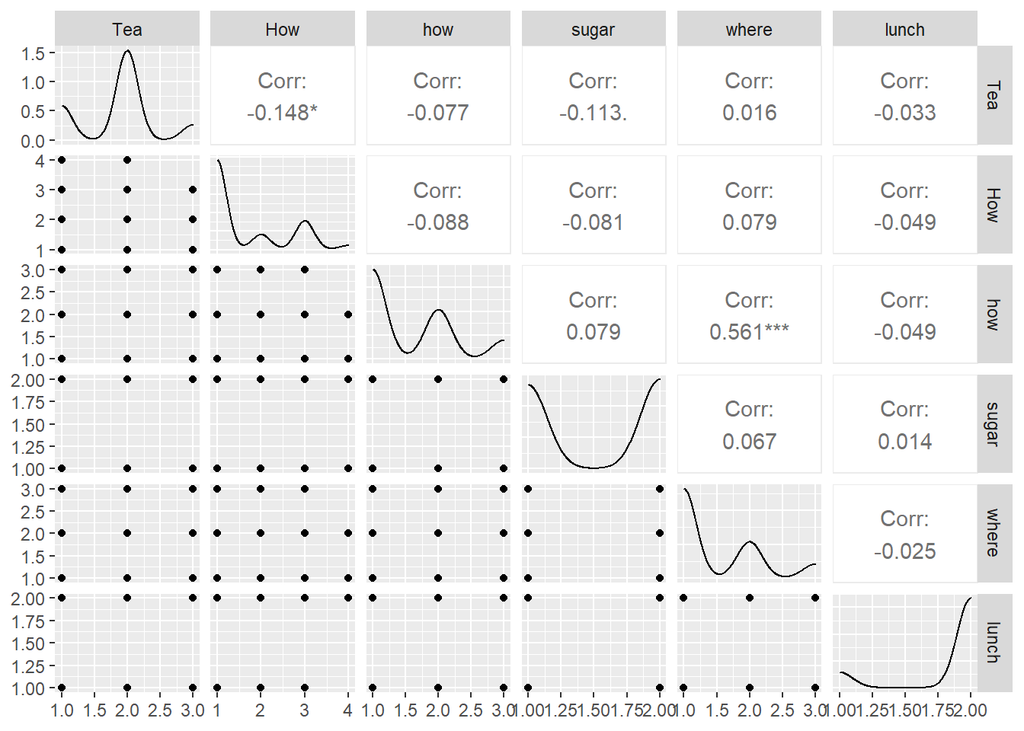

```r
p <- ggpairs(tea_timen, progress = FALSE)
p
```

```r
# multiple correspondence analysis
library(FactoMineR)
mca <- MCA(tea_time[, 1:5], graph = FALSE)

# summary of the models
summary(mca)
```

```
##
## Call:
## MCA(X = tea_time[, 1:5], graph = FALSE)
##
##
## Eigenvalues
##                        Dim.1   Dim.2   Dim.3   Dim.4   Dim.5   Dim.6   Dim.7
## Variance               0.335   0.309   0.257   0.224   0.198   0.184   0.172
## % of var.             16.762  15.441  12.866  11.181   9.924   9.188   8.625
## Cumulative % of var.  16.762  32.204  45.069  56.250  66.174  75.362  83.987
##                        Dim.8   Dim.9  Dim.10
## Variance               0.141   0.105   0.075
## % of var.              7.031   5.249   3.734
## Cumulative % of var.  91.017  96.266 100.000
##
## Individuals (the 10 first)
##                       Dim.1    ctr   cos2    Dim.2    ctr   cos2    Dim.3
## 1                  | -0.325  0.105  0.088 | -0.288  0.090  0.069 |  0.305
## 2                  | -0.259  0.067  0.037 | -0.074  0.006  0.003 |  0.789
## 3                  | -0.403  0.162  0.242 | -0.283  0.086  0.119 |  0.217
## 4                  | -0.580  0.334  0.481 | -0.328  0.116  0.154 | -0.290
## 5                  | -0.403  0.162  0.242 | -0.283  0.086  0.119 |  0.217
## 6                  | -0.403  0.162  0.242 | -0.283  0.086  0.119 |  0.217
## 7                  | -0.403  0.162  0.242 | -0.283  0.086  0.119 |  0.217
## 8                  | -0.259  0.067  0.037 | -0.074  0.006  0.003 |  0.789
## 9                  |  0.155  0.024  0.012 |  0.974  1.025  0.461 | -0.005
## 10                 |  0.521  0.270  0.142 |  0.845  0.770  0.373 |  0.612
##                       ctr   cos2
## 1                   0.120  0.078 |
## 2                   0.806  0.343 |
## 3                   0.061  0.070 |
## 4                   0.109  0.120 |
## 5                   0.061  0.070 |
## 6                   0.061  0.070 |
## 7                   0.061  0.070 |
## 8                   0.806  0.343 |
## 9                   0.000  0.000 |
## 10                  0.485  0.196 |
##
## Categories (the 10 first)
```

[output cut: 15 more lines]

```
## alone               -5.905 |   0.150   1.136   0.042   3.534 |
## lemon                2.787 |  -1.561  20.842   0.301  -9.491 |
## milk                 1.963 |   0.093   0.141   0.002   0.828 |
## other                6.712 |   1.826   7.773   0.103   5.552 |
## tea bag             -6.637 |   0.069   0.211   0.006   1.367 |
## tea bag+unpackaged  11.677 |  -0.050   0.061   0.001  -0.586 |
## unpackaged          -6.548 |  -0.196   0.357   0.005  -1.249 |
##
## Categorical variables (eta2)
##                      Dim.1 Dim.2 Dim.3
## Tea                | 0.126 0.115 0.421 |
## How                | 0.076 0.220 0.385 |
## how                | 0.708 0.503 0.008 |
## sugar              | 0.065 0.004 0.412 |
## where              | 0.701 0.702 0.061 |
```

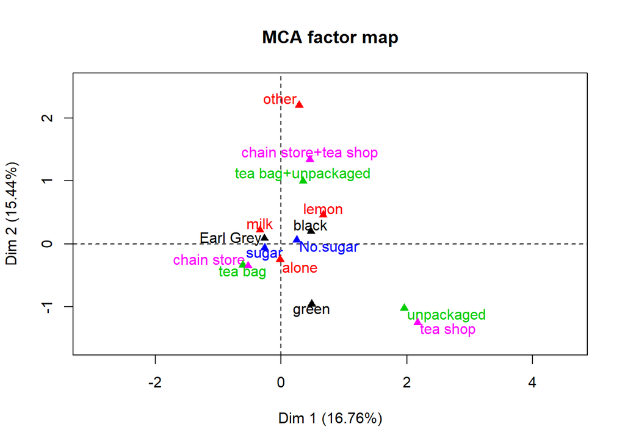

```r
# visualize MCA
plot(mca, invisible=c("ind"), habillage = "quali", graph.type = "classic")
```

The tea_time variables are rather weakly associated with each other. The only exception is the association between how tea is used/purchased (as a tea bag or unpacked) and where it is bought (from a chain store or a tea shop). In the MCA factor map, the classes stay mostly close to the origo implying that very much distinction cannot be found based on these variables. Yet, it hints that some users tend to use their tea as green bought unpackaged from a tea shop, some like their tea as Earl Grey (bought as tea bags from chain stores) with sugar and milk and some like it black with lemon and no sugar. The classes ‘other’ and ‘chain store + tea shop’ and ‘tea bag + unpackaged’ seem to be distinctive from others but are rather impossible to interpret due to their mixed natures.